# Taller: Árboles de decisión

En este taller analizaremos aspectos de árboles de decisión para varios conjuntos de datos. El primero es el [Play tennis dataset](https://www.kaggle.com/datasets/fredericobreno/play-tennis). El segundo es el [Iris dataset](https://archive.ics.uci.edu/ml/datasets/iris). El tercero es el [Pima Indians Diabetes Database](https://www.kaggle.com/datasets/uciml/pima-indians-diabetes-database). El cuarto es [Hitters](https://www.kaggle.com/datasets/floser/hitters).

El taller consiste en realizar todas las tareas numeradas del 1 al 13. Cargar el cuaderno ejecutado y guardado en formato .ipynb y en formato .HTML a más tardar el martes 22 de agosto a las 11:00am.

```python
#Importar librerías
import pandas as pd
from sklearn.datasets import load_iris
from sklearn.model_selection import train_test_split
from sklearn.tree import DecisionTreeClassifier, plot_tree, DecisionTreeRegressor
from sklearn import metrics
import matplotlib.pyplot as plt
```

## Tennis Dataset

En primer lugar, cargar y leer el conjunto de datos Play Tennis, e imprimir todas sus filas (son pocas).

```python
#Leer el Play tennis dataset.
df=pd.read_csv("play_tennis.csv")
df.drop('day', inplace=True, axis=1)

#Mostrar todas sus filas.
print(df)
```

```
     outlook  temp humidity    wind play
0      Sunny   Hot     High    Weak   No
1      Sunny   Hot     High  Strong   No
2   Overcast   Hot     High    Weak  Yes
3       Rain  Mild     High    Weak  Yes
4       Rain  Cool   Normal    Weak  Yes
5       Rain  Cool   Normal  Strong   No
6   Overcast  Cool   Normal  Strong  Yes
7      Sunny  Mild     High    Weak   No
8      Sunny  Cool   Normal    Weak  Yes
9       Rain  Mild   Normal    Weak  Yes
10     Sunny  Mild   Normal  Strong  Yes
11  Overcast  Mild     High  Strong  Yes
12  Overcast   Hot   Normal    Weak  Yes
13      Rain  Mild     High  Strong   No
```

El clasificador de árboles de decisión de SKLearn recibe únicamente atributos numéricos. Dado que todos los atributos de este dataset son categorías determinadas por datos tipo *string* necesitamos codificar estas categorías con el método one hot encoding, el cual hemos discutido en clase (si no lo recuerda, puede preguntarme). Una forma de hacer esto en Python es utilizando la función *get_dummies* de Pandas.

El parámetro *drop_first=True* remueve una de las columnas generadas en cada variable, pues ésta realmente reundaría con las demás.

```python
df=pd.get_dummies(df, drop_first=True)
```

```python
df
```

|  | outlook_Rain | outlook_Sunny | temp_Hot | temp_Mild | humidity_Normal | wind_Weak | play_Yes |
| --- | --- | --- | --- | --- | --- | --- | --- |
| 0 | 0 | 1 | 1 | 0 | 0 | 1 | 0 |
| 1 | 0 | 1 | 1 | 0 | 0 | 0 | 0 |
| 2 | 0 | 0 | 1 | 0 | 0 | 1 | 1 |
| 3 | 1 | 0 | 0 | 1 | 0 | 1 | 1 |
| 4 | 1 | 0 | 0 | 0 | 1 | 1 | 1 |
| 5 | 1 | 0 | 0 | 0 | 1 | 0 | 0 |
| 6 | 0 | 0 | 0 | 0 | 1 | 0 | 1 |
| 7 | 0 | 1 | 0 | 1 | 0 | 1 | 0 |
| 8 | 0 | 1 | 0 | 0 | 1 | 1 | 1 |
| 9 | 1 | 0 | 0 | 1 | 1 | 1 | 1 |
| 10 | 0 | 1 | 0 | 1 | 1 | 0 | 1 |
| 11 | 0 | 0 | 0 | 1 | 0 | 0 | 1 |
| 12 | 0 | 0 | 1 | 0 | 1 | 1 | 1 |
| 13 | 1 | 0 | 0 | 1 | 0 | 0 | 0 |

Imprima el dataset codificado y asegúrese de que es clara la función get_dummies. Por ejemplo, ¿cómo habría quedado el dataset si no le hubieramos dado el valor de verdadero al parámetro drop_first?

Nos hubiera mostrado cada categoría de las diferentes columnas, lo cual es redundante. Además, lo que se busca es que la tabla se minimice.

#### Cálculo de la ganancia de información

1. De acuerdo a lo visto en clase, cacular la ganancia de información para cada uno de los atributos del dataset: $Gain(S,A)=Ent(S)-\sum_{v\in values(A)}\frac{|S_v|}{|S|}Ent(S_v)$.

   ¿Cuál sería el mejor atributo para comenzar el árbol? Observación: Puede hacer sus cálculos a mano y adjuntar una imagen de los mismos, o programar.

```python
import numpy as np
df=pd.read_csv("play_tennis.csv")
df.drop('day', inplace=True, axis=1)

# Función para calcular la entropía
def entropy(target_col):
    elements, counts = np.unique(target_col, return_counts=True)
    entropy = -np.sum([(counts[i]/np.sum(counts)) * np.log2(counts[i]/np.sum(counts)) for i in range(len(elements))])
    return entropy

# Función para calcular la ganancia de información
def gain(data, attribute, target):
    total_entropy = entropy(data[target])
    values, counts = np.unique(data[attribute], return_counts=True)
    weighted_entropy = np.sum([(counts[i]/np.sum(counts)) * entropy(data.where(data[attribute]==values[i]).dropna()[target]) for i in range(len(values))])
    information_gain = total_entropy - weighted_entropy
    return information_gain

target_attribute = 'play'
attributes = df.columns.tolist()
attributes.remove(target_attribute)

for attribute in attributes:
    info_gain = gain(df, attribute, target_attribute)
    print(f"Information Gain for {attribute}: {info_gain}")
```

```
Information Gain for outlook: 0.24674981977443933
Information Gain for temp: 0.02922256565895487
Information Gain for humidity: 0.15183550136234159
Information Gain for wind: 0.04812703040826949
```

#### Construcción de un primer modelo de árbol de clasificación.

Para el casos de clasificación, como lo es el del dataset Play tennis, utilizaremos el algoritmo *DecisionTreeClassifier* De SKLearn. Como el dataset es tan pequeño, en este primer caso construiremos el modelo cutilizando el dataset completo como conjunto de entrenamiento.

1. Defina como *y* la columna de la variable objetivo, y defina como *X* el dataset *sin* la columna de la varible objetivo.

```python
# Definir X,y
# Definir y (variable objetivo) y X (características)
df=pd.get_dummies(df, drop_first=True)
y = df['play_Yes']
X = df.drop('play_Yes', axis=1)
```

```python
#Se define el clasificador
clf = DecisionTreeClassifier(random_state=0,criterion='entropy')
#Se entrena el clasificador
clf.fit(X,y)
```

```
DecisionTreeClassifier(criterion='entropy', random_state=0)
```

A continuación, utilizamos el módulo *pyplot* y la función *plot_tree* para graficar el modelo arrojado por el algoritmo, a saber, el árbol de decisión que se obtiene como salida.

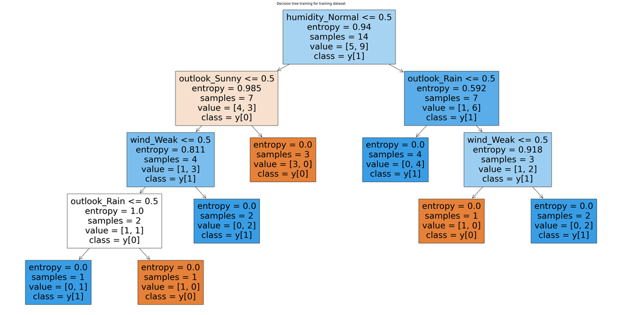

```python
#Se establece el tamaño del diagrama
plt.figure(figsize=(40,20))
#Se grafica el árbol
#filled le da colores a los nodos
#feature_names recibe los nombres de los atributos para que se vean en el árbol
#class_names imprime la clase de cada hoja en el árbol
plot_tree(clf, filled=True, feature_names=list(X.columns),class_names=True)
#Título de la gráfica
plt.title("Decision tree training for training dataset")
#Imprimir la gráfica
plt.show()
```

1. Observe el árbol generado y extraiga la información que éste le brinda. Si hay algo que no comprende de la gráfica puede investigar o preguntar. Escriba la información que encuentre relevante sobre éste árbol. ¿El árbol arrancó por el atributo que usted obtuvo como aquel que aporta más información?

No, puesto que sólo calculamos la ganancia de información con el dataframe original. Al generar las variable dummies, humidity_normal pasa a tener más peso que outlook. Por otro lado, también podemos observar que el color se vuelve más intenso a medida que alcanza la "pureza".

## Árbol de decisión para clasificación del Iris Dataset

En el taller anterior hemos cargado el dataset desde nuestros archivos locales. Sin embargo, SkLearn también nos provee de conjuntos de datos, los cuales podemos cargar directamente utilizando Python.

1. Investigue cómo cargar un dataset de SKLearn (se vale ChatGPT! ¿Por qué no?). Cargue el iris dataset. Guardar en X,y las variables de entrada y salida respectivamente, en tipo DataFrame. Separe en conjuntos de entrenamiento y testeo (*X_train, X_test, y_train, y_test*) en una proporción de 70% y 30%.

```python
#Importar el Iris Dataset usando load_iris de sklearn (ya se importó load_iris). Darle el nombre 'iris'.
# Guardar en X,y las variables de entrada y salida respectivamente, en tipo DataFrame.
# Usar iris.data, iris.target.

# Cargar el conjunto de datos Iris
iris = load_iris()

# Crear un DataFrame para las variables de entrada
X = pd.DataFrame(iris.data, columns=iris.feature_names)

# Crear una Serie para las etiquetas de salida
y = pd.Series(iris.target, name='target')

# Combinar X e y en un único DataFrame
iris_df = pd.concat([X, y], axis=1)

# Mostrar las primeras filas del DataFrame
print(iris_df.head())
```

```
   sepal length (cm)  sepal width (cm)  petal length (cm)  petal width (cm)  \
0                5.1               3.5                1.4               0.2
1                4.9               3.0                1.4               0.2
2                4.7               3.2                1.3               0.2
3                4.6               3.1                1.5               0.2
4                5.0               3.6                1.4               0.2

   target
0       0
1       0
2       0
3       0
4       0
```

```python
#Separar en Train y Test set con una proporción de 70%-30%.
# Dividir el conjunto de datos en entrenamiento y prueba
X_train, X_test, y_train, y_test = train_test_split(X, y, test_size=0.3, random_state=42)
```

1. Definir un clasificador de árbol de decisión con DecisionTreeClassifier de SKlearn. Utilice el criterio 'entropy'. Fije una semilla aleatoria (random_state) para obtener los mismos resultados cada vez que corra el cuderno. Entrenar el Clasificador **con el conjunto de entrenamiento**.

```python
#Definir un clasificador de árbol de decisión con DecisionTreeClassifier de SKLearn.
#Fije un random_state y utilice criterion='entropy'
#Entrenarlo

# Definir el clasificador de árbol de decisión
clf = DecisionTreeClassifier(random_state=42, criterion='entropy')

# Entrenar el clasificador utilizando el conjunto de entrenamiento
clf.fit(X_train, y_train)
```

```
DecisionTreeClassifier(criterion='entropy', random_state=42)
```

Es posible medir este modelo usando la métrica *accuracy*: la proporción entre predicciones correctas y el total de predicciones.

```python
#Calcular predicciones para el conjunto de testeo.
y_pred = clf.predict(X_test)
print("Accuracy:",metrics.accuracy_score(y_test, y_pred))
```

```
Accuracy: 0.9777777777777777
```

Graficamos el árbol obtenido mediante el uso de plot_tree.

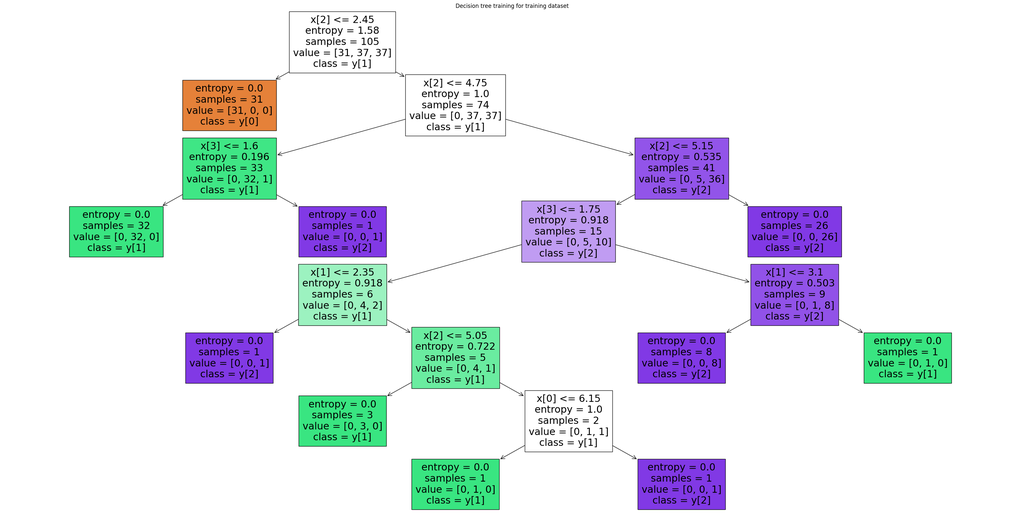

```python
plt.figure(figsize=(40,20))
plot_tree(clf, filled=True, class_names=True)
plt.title("Decision tree training for training dataset")
plt.show()
```

1. Explore algunos métodos del DecisionTreeClassifier como apply, get_depth, get_n_leaves, para el modelo obtenido. Imprímalos y corrobore su resultado usando el diagrama del árbol. Explique lo que hace cada uno de estos métodos.

```
Resultados:
Predicciones: [ 4  1 18  4 11  1  4 16  4  4 17  1  1  1  1  4 18  4  4 18  1 16  1 18
 18 18 18 18  1  1  1  1  4  1  1 16  4  1  1  1 16  4  4  1  1]
Profundidad máxima del árbol: 7
Número de hojas del árbol: 10
```

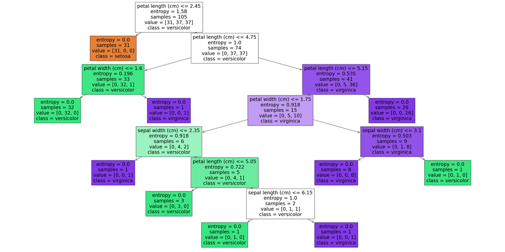

```python
# Aplicar métodos apply, get_depth, get_n_leaves y entender lo que dicen del árbol.
# Usar el método apply para obtener las predicciones de las instancias de prueba
predictions = clf.apply(X_test)

# Usar el método get_depth para obtener la profundidad máxima del árbol
max_depth = clf.get_depth()

# Usar el método get_n_leaves para obtener el número de hojas del árbol
n_leaves = clf.get_n_leaves()

# Imprimir los resultados
print("Resultados:")
print("Predicciones:", predictions)
print("Profundidad máxima del árbol:", max_depth)
print("Número de hojas del árbol:", n_leaves)

# Graficar el árbol para una mejor comprensión visual
plt.figure(figsize=(40, 20))
plot_tree(clf, filled=True, feature_names=iris.feature_names, class_names=iris.target_names)
plt.show()
```

- **Método apply:** Este método se utiliza para obtener las identificaciones de nodo de las hojas correspondientes a las instancias proporcionadas. Las identificaciones de nodo son índices que indican qué hoja del árbol se alcanza para cada instancia. Las predicciones pueden ser más eficientes de calcular utilizando este método en lugar de predict, especialmente cuando se tiene un gran conjunto de datos.
- **Método get_depth:** Este método devuelve la profundidad máxima del árbol. La profundidad de un árbol de decisión se mide desde la raíz hasta la hoja más profunda. Una mayor profundidad puede indicar un árbol más complejo y propenso al sobreajuste.
- **Método get_n_leaves:** Este método devuelve el número total de hojas en el árbol. Las hojas son los nodos finales del árbol donde se hacen las predicciones. El número de hojas es un indicador de la complejidad del árbol y puede estar relacionado con el potencial de sobreajuste.

## Diabetes dataset

A continuación, enntrene un árbol de decisión para el conjunto de datos sobre diabetes.

1. Entrene un árbol de decisión utilizando el clasificador de SKLearn con un conjunto de entrenamiento del 80% del dataset. Utilice random_state=0 y el criterio de entropía. Grafique el árbol. ¿Cuál es la precisión de este modelo?

```python
d = pd.read_csv('diabetes.csv').dropna()
y = d.Outcome
X = d.drop(columns=['Outcome'])
X_train, X_test, y_train, y_test = train_test_split(X,y,random_state=0,test_size=0.2)
dia = DecisionTreeClassifier(random_state = 0,criterion = 'entropy')
dia.fit(X_train, y_train)
```

```
DecisionTreeClassifier(criterion='entropy', random_state=0)
```

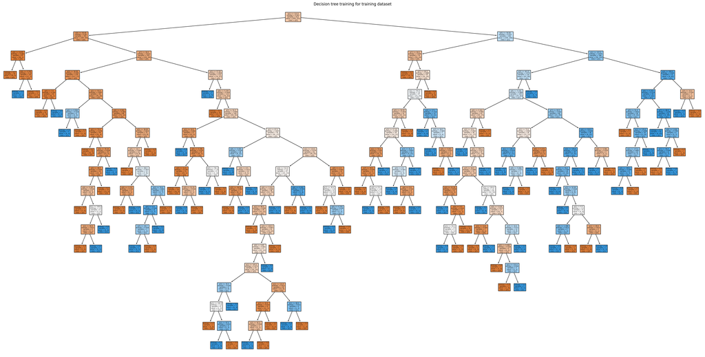

```python
plt.figure(figsize=(40,20))
plot_tree(dia, filled=True, class_names=True)
plt.title("Decision tree training for training dataset")
plt.show()
```

### Poda del árbol

Uno de los parámetros del DecisionTreeClassifier es *ccp_alpha*, el cual es un parámetro para la poda del árbol mediante el método *Mínimal cost complexity*. El código siguiente arroja una lista de valores de alpha que resultan efectivos en la poda del árbol.

Entre mayor es el valor de $\alpha$, más se poda el árbol.

```python
path = clf.cost_complexity_pruning_path(X_train, y_train)
ccp_alphas, impurities = path.ccp_alphas, path.impurities
ccp_alphas
```

```
array([0.        , 0.00325733, 0.00325733, 0.00325733, 0.00354114,
       0.00434311, 0.00448679, 0.00448679, 0.00448679, 0.00448679,
       0.00448679, 0.0046164 , 0.00468704, 0.0048303 , 0.0048303 ,
       0.00495964, 0.00502633, 0.0052852 , 0.0055433 , 0.00560085,
       0.00575644, 0.00587467, 0.00587889, 0.00594704, 0.00602679,
       0.00604632, 0.00604745, 0.00605368, 0.00618329, 0.00640444,
       0.0064094 , 0.00654328, 0.00655698, 0.00674546, 0.00684674,
       0.00690069, 0.00697625, 0.00702367, 0.00737675, 0.00768763,
       0.00785562, 0.00787552, 0.00812098, 0.00818056, 0.0086791 ,
       0.00869433, 0.00897357, 0.00914306, 0.00924392, 0.00994398,
       0.01118351, 0.01151191, 0.0120048 , 0.01282652, 0.02102938,
       0.02130657, 0.0278788 , 0.03683399, 0.04500223, 0.13153424])
```

1. Usando el arreglo de valores de *ccp_alpha* arrojados en la celda anterior, crear un loop que entrene un árbol para cada parámetro de ccp_alpha e imprima su precisión. De esta lista, extraer el valor de ccp_alpha optimo.

```python
for alpha in ccp_alphas:
    X_train, X_test, y_train, y_test=train_test_split(X, y, test_size = 0.2,random_state=0)
    diab = DecisionTreeClassifier(random_state = 0,criterion = 'entropy',ccp_alpha = alpha)
    diab.fit(X_train,y_train)
    y_pred = diab.predict(X_test)
    print("Accuracy:",metrics.accuracy_score(y_test, y_pred),"alpha: ",alpha)
```

```
Accuracy: 0.7077922077922078 alpha:  0.0
Accuracy: 0.7207792207792207 alpha:  0.003257328990228013
Accuracy: 0.7207792207792207 alpha:  0.003257328990228013
Accuracy: 0.7207792207792207 alpha:  0.003257328990228013
Accuracy: 0.7207792207792207 alpha:  0.003541136437782387
Accuracy: 0.7142857142857143 alpha:  0.004343105320304018
Accuracy: 0.7142857142857143 alpha:  0.004486787462806952
Accuracy: 0.7142857142857143 alpha:  0.004486787462806952
Accuracy: 0.7142857142857143 alpha:  0.004486787462806952
Accuracy: 0.7142857142857143 alpha:  0.004486787462806952
Accuracy: 0.7142857142857143 alpha:  0.004486787462806952
Accuracy: 0.7142857142857143 alpha:  0.0046163955311671785
Accuracy: 0.7207792207792207 alpha:  0.0046870367403543675
Accuracy: 0.7207792207792207 alpha:  0.0048302967486052156
Accuracy: 0.7207792207792207 alpha:  0.004830296748605221
Accuracy: 0.7207792207792207 alpha:  0.004959635958376633
Accuracy: 0.7272727272727273 alpha:  0.0050263295230949905
Accuracy: 0.7142857142857143 alpha:  0.005285199507877087
Accuracy: 0.7142857142857143 alpha:  0.005543302733648896
Accuracy: 0.7207792207792207 alpha:  0.005600847360405197
Accuracy: 0.7207792207792207 alpha:  0.005756438074987935
Accuracy: 0.7207792207792207 alpha:  0.005874670755539026
Accuracy: 0.7207792207792207 alpha:  0.005878893280841712
Accuracy: 0.7142857142857143 alpha:  0.00594704308534728
Accuracy: 0.7142857142857143 alpha:  0.0060267930677611395
Accuracy: 0.7142857142857143 alpha:  0.006046320073832434
Accuracy: 0.7272727272727273 alpha:  0.00604744634202081
Accuracy: 0.7272727272727273 alpha:  0.006053678869362694
Accuracy: 0.7207792207792207 alpha:  0.0061832869377229215
Accuracy: 0.7207792207792207 alpha:  0.006404437249300772
Accuracy: 0.7207792207792207 alpha:  0.006409400892539968
Accuracy: 0.7207792207792207 alpha:  0.006543278194560575
Accuracy: 0.7207792207792207 alpha:  0.006556977630964112
Accuracy: 0.7207792207792207 alpha:  0.006745455130417414
Accuracy: 0.7402597402597403 alpha:  0.006846737872456488
Accuracy: 0.7402597402597403 alpha:  0.006900690134768748
Accuracy: 0.7402597402597403 alpha:  0.006976252280378801
Accuracy: 0.7402597402597403 alpha:  0.0070236661112516655
Accuracy: 0.7402597402597403 alpha:  0.007376750835473635
Accuracy: 0.7402597402597403 alpha:  0.007687632265982233
Accuracy: 0.7402597402597403 alpha:  0.007855623676377606
Accuracy: 0.7402597402597403 alpha:  0.007875517674348383
Accuracy: 0.7272727272727273 alpha:  0.008120983138838862
Accuracy: 0.7402597402597403 alpha:  0.008180559487454442
Accuracy: 0.7467532467532467 alpha:  0.008679096965705041
Accuracy: 0.7467532467532467 alpha:  0.008694333854881928
Accuracy: 0.7402597402597403 alpha:  0.008973574925613905
Accuracy: 0.7337662337662337 alpha:  0.009143064340913026
Accuracy: 0.7532467532467533 alpha:  0.009243915459318366
Accuracy: 0.7532467532467533 alpha:  0.009943975646005479
Accuracy: 0.7532467532467533 alpha:  0.011183514974848457
Accuracy: 0.7792207792207793 alpha:  0.011511908800140969
Accuracy: 0.7727272727272727 alpha:  0.012004800622679931
Accuracy: 0.7597402597402597 alpha:  0.012826517710630762
Accuracy: 0.7597402597402597 alpha:  0.021029382648115505
Accuracy: 0.7597402597402597 alpha:  0.021306568283758043
Accuracy: 0.7597402597402597 alpha:  0.02787879900735951
Accuracy: 0.7207792207792207 alpha:  0.036833986646986505
Accuracy: 0.7207792207792207 alpha:  0.04500222816035104
Accuracy: 0.6948051948051948 alpha:  0.1315342361726266
```

1. Entrenar un clasificador con el ccp_alpha óptimo. Graficarlo y compararlo con el árbol inicial.

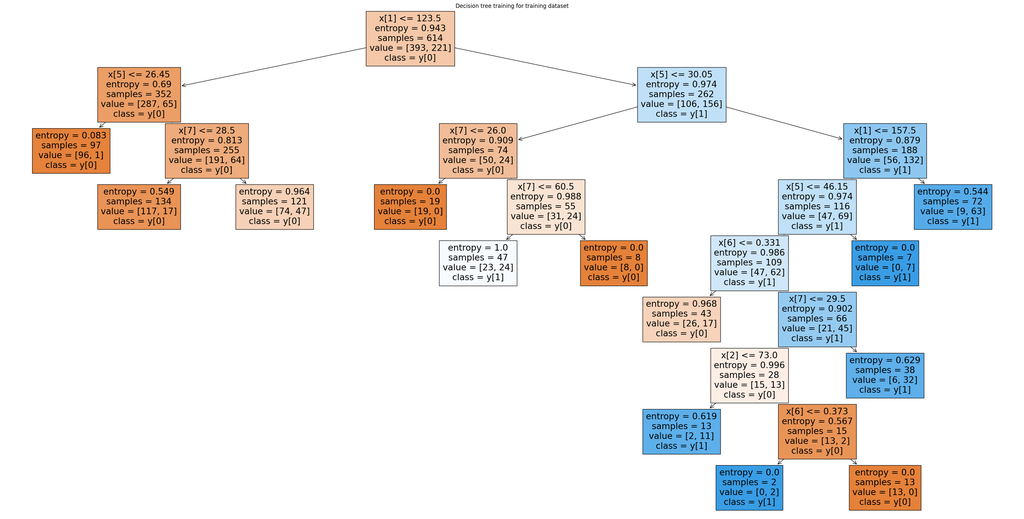

```python
X_train, X_test, y_train, y_test=train_test_split(X, y, test_size = 0.2,random_state=0)
diab = DecisionTreeClassifier(random_state = 0,criterion = 'entropy',ccp_alpha = 0.011511908800140969)
diab.fit(X_train,y_train)

plt.figure(figsize=(40,20))
plot_tree(diab, filled=True, class_names=True)
plt.title("Decision tree training for training dataset")
plt.show()
```

Tenemos que el primer árbol esta sobre ajustado. Por eso es más conveniente nuestro segundo árbol, ya que ha este se la ha realizado la poda.

## Árbol de regresión

Para éste ejercicio usamos el dataset de Hitters, cuya variable objetivo es el salario, el cual no es una variable categórica. Para esto necesitamos un árbol de regresión, a saber, el algoritmo *DecisionTreeRegressor* de SKLearn.

Primero leemos el dataset, y eliminamos los valores faltantes, pues este algoritmo no los maneja. Consideraremosmos como entrada X únicamente dos de sus variables: Years, Hits. Tomamos como variable objetivo el salario.

```python
# Se lee el dataset y se omiten los registros con valores faltantes.
df = pd.read_csv('Hitters.csv').dropna()

#Se imprime información sobre dicho dataset.
df.info()
```

```
<class 'pandas.core.frame.DataFrame'>
Int64Index: 263 entries, 1 to 321
Data columns (total 20 columns):
 #   Column     Non-Null Count  Dtype
---  ------     --------------  -----
 0   AtBat      263 non-null    int64
 1   Hits       263 non-null    int64
 2   HmRun      263 non-null    int64
 3   Runs       263 non-null    int64
 4   RBI        263 non-null    int64
 5   Walks      263 non-null    int64
 6   Years      263 non-null    int64
 7   CAtBat     263 non-null    int64
 8   CHits      263 non-null    int64
 9   CHmRun     263 non-null    int64
 10  CRuns      263 non-null    int64
 11  CRBI       263 non-null    int64
 12  CWalks     263 non-null    int64
 13  League     263 non-null    object
 14  Division   263 non-null    object
 15  PutOuts    263 non-null    int64
 16  Assists    263 non-null    int64
 17  Errors     263 non-null    int64
 18  Salary     263 non-null    float64
 19  NewLeague  263 non-null    object
dtypes: float64(1), int64(16), object(3)
memory usage: 43.1+ KB
```

```python
#Se toman sólo dos de las columnas
X = df[['Years', 'Hits']]
y = df.Salary
```

1. Entrenar un árbol de regresión en X,y con el parámetro max_leaf_nodes=3; usar el método score (coeficiente de determinación) para medir su desempeño, y graficar el árbol.

```python
# Tomar las columnas Years y Hits como variables de entrada
X = df[['Years', 'Hits']]
y = df['Salary']

# Entrenar un árbol de regresión con max_leaf_nodes=3
regressor = DecisionTreeRegressor(max_leaf_nodes=3)
regressor.fit(X, y)

# Medir el desempeño utilizando el coeficiente de determinación (score)
score = regressor.score(X, y)
print("Coeficiente de determinación:", score)
```

```
Coeficiente de determinación: 0.43665573627391885
```

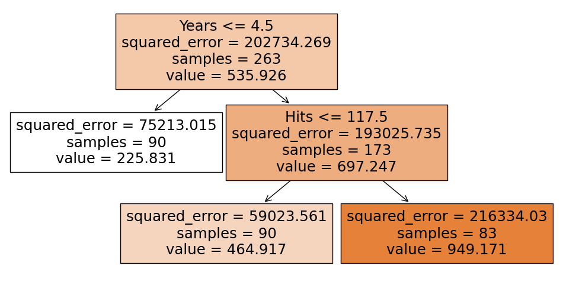

```python
## Graficar el árbol
plt.figure(figsize=(12, 6))
plot_tree(regressor, filled=True, feature_names=['Years', 'Hits'])
plt.show()
```

1. ¿En cuántas regiones $R_i$ separó el espacio de las dos variables de entrada el árbol anterior? Descríbalas.

El número de regiones en las que un árbol de decisión divide el espacio de las variables de entrada está relacionado con el número de hojas del árbol. En este caso, debido a que se limitó el árbol a tener un máximo de 3 hojas usando el parámetro max_leaf_nodes=3, el árbol dividirá el espacio en exactamente 3 regiones

1. Escriba sus conclusiones o preguntas sobre el ejercicio.
- Lo primero que debemos hacer cuando queremos hacer nuestro modelo es utilizar la función get_dummies de pandas, ya que esta nos ayuda a organizar nuestros datos de manera que remueve una columna generada por cada variable para que no sea redundante. Por otro lado, se puede escoger cualquier columna, pero esta función elimina la primera.
- En algunos casos, luego de mirar la ganancia de cada variable, la de mayor resultado no se escoge como nodo inicial. Ya que este no es único factor que se tiene en cuenta a la hora de escogerlo. Además, en este caso, nosotros sacamos la ganancia sin utilizar la función get_dummies, y al remover las columnas las variables pueden perder o ganar ganancia, afectando así la posición de las variables en el árbol.
- No es conveniente trabajar con árbol muy grande o sobre ajustado, para solucionar este problema podemos podar el árbol.